# Processo de Poisson não-homogêneo

Gustavo Almeida Silva

06/08/2022

# Definição de um Processo de Poisson não-homogêneo

O processo de Poisson é um processo de contagem, ou seja, ele busca quantificar quantas observações foram registradas em algum determinado espaço de tempo. Esse processo possui propriedades importantíssimas, onde a função desenvolvida neste trabalho para simular um Processo de Poisson, se utiliza delas:

- Propriedade de falta de memória
  - Diz respeito à estrutura condicional do processo, onde a probabilidade de ocorrer alguma observação entre os tempos $T_k$ e $T_{k+1}$ é independente do número de observações registradas entre $T_0$ e $T_k$
- Propriedade do Tempo de Chegada: distribuição e independência
  - O intervalo de tempo entre a chegada de 2 observações seguem uma distribuição Exponencial, onde por conta do processo possuir a propriedade de falta de memória, esses $T_i$ são IID. Assim, a soma de tempos de chegada segue uma Gama

Em uma simulação de um Processo de Poisson é necessário conhecer a taxa de tempo em que essas observação ocorrem, onde em um **Processo de Poisson não-homogêneo* essa taxa é dada em função do tempo

# A utilização da programação funcional

O trabalho desenvolvido nesse relatório tem em seu objetivo desenvolver funções para a simulação de eventos que possam ser modelados por um **Processo de Poisson não-homogêneo**

Entre exemplos que podem utilizar esse modelos estão:

- Tempo de chegada entre maratonistas
- Quantidade de carros que passam por um determinado radar
- Erros em algum programa de computador

(Voltaremos em alguns desses casos na seção **Exemplos**)

Assim, existe uma ampla gama de casos onde a abordagem via Processo de Poisson pode ser bem-vinda, e visando uma possível disponibilização de um pacote com as funções desenvolvidas aqui, utilizaremos o conceito da **programação funcional** para uma construção que visa encapsular certas funções, facilitar a leitura dos codigos e otimizar a busca por possíveis erros.

Iremos seguir a seguinte metodologia:

- Funções pequenas
  - Prática de separar o algoritmo em funções cada vez mais simples e que naturalmente irá reduzir o tamanho de cada função
- Função e finalidade
  - Funções devem possuir uma única finalidade, ou seja, não basta simplesmente dividir uma função por conta do seu tamanho, ao particionar uma função em outras menores o foco deve ser justamente o unicidade parâmetro de saída.
- Encapsulamento
  - A função disponivel para uso é a chamada de outras funções menores

Seguindo esses conceitos, foram desenvolvidas 4 funções para utilização do usuário

- *nhpp_simulation(lambda_function,t_initial,t_final)*
  - Se trata da função principal desenvolvida nesse trabalho, onde ela possui a finalidade de simular um Processo de Poisson não-homogeneo. É necessário a utilização de 3 argumentos: **lambda_function**: é a função de intensidade de *lambda*, ela deve ser continua no intervalo de simulação solicitado, **t_initial**: é o momento inicial da simulação, **t_final**: é o momento final da simulação
- *nhpp_view(data)*
  - É uma função que busca facilitar a visualização gráfica dos dados gerados pela função de simulação É necessário a utilização de 1 argumento: **data**: é o vetor dados que foi retornado pela função *nhpp_simulation*
- *nhpp_mean=function(lambda_function,t_initial,t_final)*
  - Se trata da função que calcula a quantidade média de chegadas em determinado intervalo de tempo É necessário a utilização de 3 argumentos: **lambda_function**, é a função de intensidade de *lambda*, ela deve ser continua no intervalo de simulação solicitado **t_initial**: é limite inferior para o calculo, **t_final**: é o limite superior para o calculo
- *nhpp_probs=function(lambda_function,t_initial,t_final,value=‘n’)*
  - Se trata da função que calcula a probabilidade de **n** chegadas em um determinado intervalo de tempo É necessário a utilização de 3 argumentos: **lambda_function**, é a função de intensidade de *lambda*, ela deve ser continua no intervalo de simulação solicitado, **t_initial**: é o momento inicial da simulação, **t_final**: é o momento final da simulação, **value**: é o valor **n** para o calculo da probabilidade. É definido como padrão, retornar a curva de probabilidade no intervalo dado, ou seja, se o o usuário não definir nenhum valor desejado, o objeto de retorno será uma função de probabilidade.

# Desenvolvimento das funções

Nessa etapa iremos apresentar a forma como cada função foi construida, mostrando tanto o código das funções disponíveis para os usuários, como também as funções internas

## Parte 1 - Função de simulação

Para construção da função de simulação de um Processo de Poisson não-homogeneo, utilizamos a base teorica disponível no livro **Simulation, de Sheldon M. Ross**, onde na seção 5.5, é descrito um metodo de simulação desse processo

Descrevendo o processo teórico:

Para simular um Processo de Poisson não-homogeneo com função de intensidade $\lambda(t)$ em um intervalo fixo [0,B], selecione uma constante $\lambda^+\geq\lambda(t)$ para todo $t \in [0,B]$ , fixe $p(t)=\frac{\lambda(t)}{\lambda^+}$

1. Gere U(0,1) V.As $u_k:k=(1,2,3,...,n^*)$, fixe $t_k=-\frac{1}{\lambda^+}log(u_k)$ e fixe $s_K=\sum_{i}^{k}t_i$ onde $k=1,2,...,n^*$ e $n*=max(n:ti\leq B)$
2. Gere u(0,1) V.As $w_j:j=(1,2,3,...,n^*)$, computando a indicadora:
   $$I_j=1$$
   para $w_j\leq\frac{\lambda(s_j)}{\lambda^+}$
   $$I_j=0$$
   caso contrário

para $j=1,2,3,...,n^*$ Selecionados com probabilidade $p(s_j)=\frac{\lambda(s_j)}{\lambda^+}$

3. Seja $J=(j:I_j=1)$, a trajetoria de contagem é $1,2,...,|J|=\sum_iI_j$ enquanto o tempo de chegado é dado por $s_j:j \in J$

Com a parte teórica definida, foi possivel desenvolver o algoritmo de simulação do processo

- Passo 1:
  - Obtendo o ponto máximo que a função de intensidade pode ter no intervalo [a,b]

```r
step1=function(lambda_function1,t_initial1=0,t_final1){
  fixed_lambda1=sapply(t_initial1:t_final1,lambda_function1)
  fixed_lambda1=max(fixed_lambda1)

  return(fixed_lambda1)
}
```

- Passo 2:
  - Calculando o valor do vetor denominado $S_K$, que será um dos argumentos do proximo passo, onde construiremos a função indicadora

```r
step2=function(size2,t_final2,fixed_lambda2){
  u=runif(size2)
  t=(-1/fixed_lambda2)*log(u)
  s_k2=cumsum(t)
  s_k2=s_k2[s_k2<t_final2]

  return(s_k2)
}
```

- Passo 3:
  - Calculando a função indicadora

```r
step3=function(size3,lambda_function3,s_k3,fixed_lambda3){
  u=runif(length(s_k3))
  indicator3=(u<=lambda_function3(s_k3)/fixed_lambda3)
  indicator3=ifelse(indicator3==T,1,0)

  return(indicator3)
}
```

- Passo 4:
  - Utilizando a função indicadora para calcular os tempos de chegada denomidados $T_K$

```r
step4=function(indicator4,s_k4){
  aux=1:sum(indicator4)
  time_arrival=which(indicator4==1)
  t_k4=s_k4[time_arrival]

  return(t_k4)
}
```

- Passo 5
  - Simulação de um processo

```r
step_generation=function(lambda_function,t_initial,t_final){
  size=10000
  s1=step1(lambda_function,t_initial,t_final)
  s2=step2(size,t_final,s1)
  s3=step3(size,lambda_function,s2,s1)
  s4=step4(s3,s2)

  return(s4)
}
```

```r
step_monte_carlo=function(lambda_function,t_initial,t_final){
  monte_carlo=unlist(replicate(30,step_generation(lambda_function,t_initial,t_final)))
  delta=t_final-t_initial
  sample_k=sort(sample(monte_carlo,delta))
  return(sample_k)

}
```

- Função ‘embalagem’
  - A chamada função embalagem é aquela que utiliza todas as outras funções definidas para construir a simulação do processo. Nela não temos nenhuma definição nova e é a unica a ser disponibilizada ao usuário (user-usable). As funções denominadas ‘steps’ são chamadas de internal functions, onde o usuario não tem acesso

```r
nhpp_simulation=function(lambda_function,t_initial,t_final){
  data=step_monte_carlo(lambda_function,t_initial,t_final)
  return(data)
}
```

- Função gráfica
  - A função definida anteriormente tem a finalidade de apenas simular um processo, e buscando facilitar a visualização gráfica dele, foi desenvolvida a função **nhpp_view**

```r
nhpp_view=function(data,col_view='red',main_text='Simulation plot'){
  plot(stepfun(data,0:length(data)),
     do.points = TRUE,
     pch = 16,
     col.points = col_view,
     verticals = FALSE,
     main = main_text,
     xlab='Time',
     ylab='Number of Arrivals'
     )
}
```

- Pequenos exemplos
  - Iremos utilizar algumas funções para $\lambda(t)$ para testar a simulação de um processo
1. $\lambda(t)=t^2$, no intervalo $[0,20]$

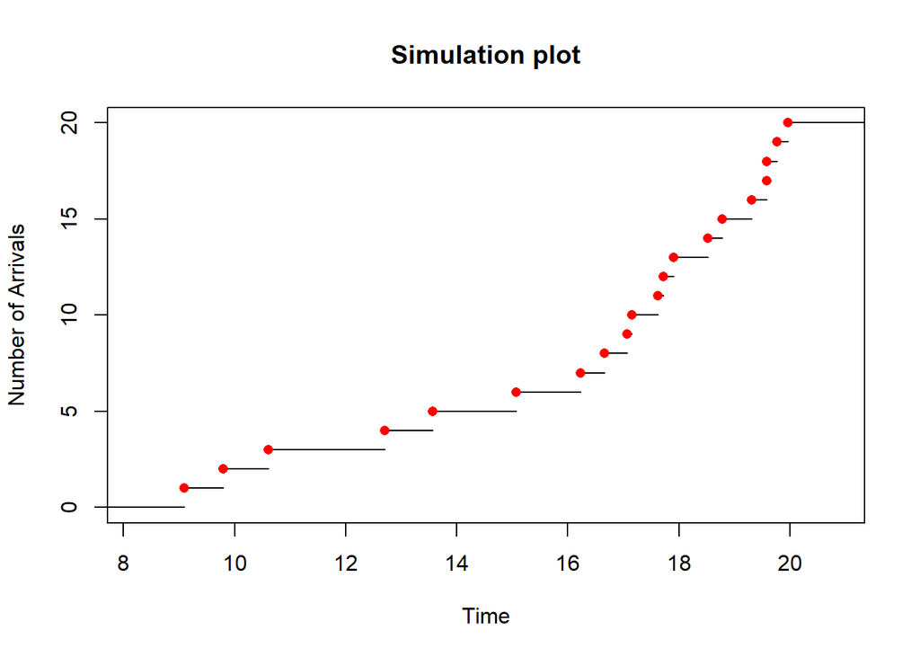

```r
lambda_t=function(t)t**2
teste=nhpp_simulation(lambda_t,0,20)
nhpp_view(teste)
```

2. $\lambda(t)=\frac{1}{t+1}$, no intervalo $[0,50]$

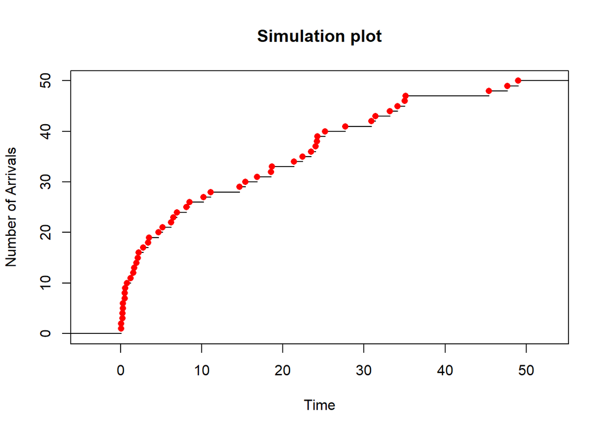

```r
lambda_t=function(t)1/(t+1)
teste=nhpp_simulation(lambda_t,0,50)
nhpp_view(teste)
```

3. $\lambda(t)=sin(t)$, no intervalo $[0,100]$

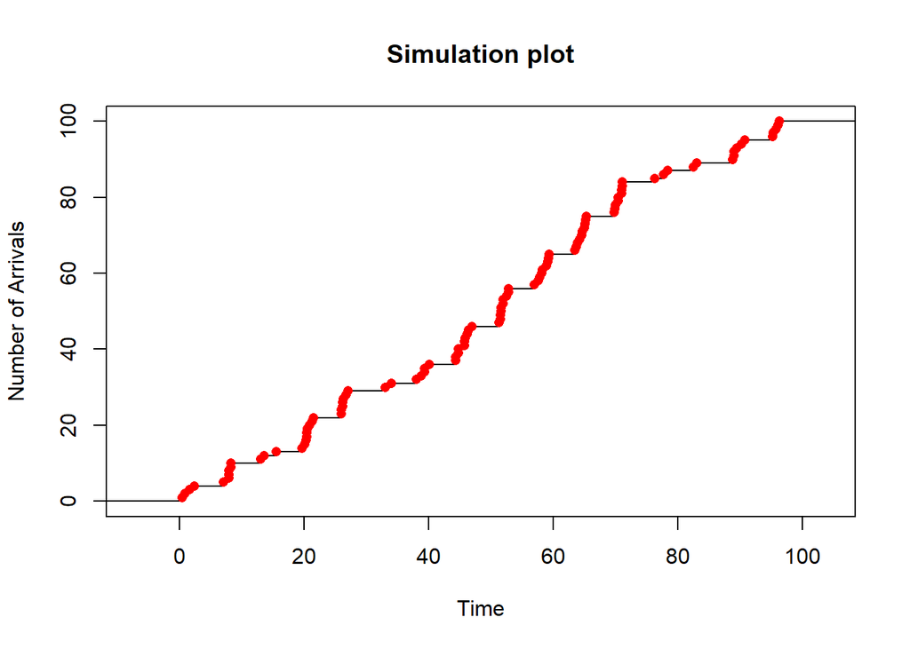

```r
lambda_t=function(t)sin(t)
teste=nhpp_simulation(lambda_t,0,100)
nhpp_view(teste)
```

## Parte 2 - Função de valor esperado e probabilidade

Buscando oferecer uma ampla gama de ferramentas para o usuário, foram desenvolvidas funções que buscam calular o **valor esperado** e a **probabilidade** de chegadas dada uma função de intensidade e um intervalo de tempo

Descrevendo o processo teórico:

1. O valor esperado do número de chegadas em um intervalo de tempo $T$ no contexto de um Processo de Poisson não-homogeneo é dado por:
   $$\int_{A}^{B}\lambda(t)dt$$
   , onde $A,B$ são tempos e $\lambda(t)$ é a função de intensidade

(como a natureza da função definida pelo usuário para $\lambda(t)$ é desconhecida, calcularemos essa integral via metodo **monte-carlo**, onde a função apresentou uma ótima convergencia para o valor teórico utilizando uma simulação uniforme>=1000)

```r
step_integral=function(func,a,b){
  size=5000
  u=runif(size,min=a,max=b)
  y_func=func(u)
  y_mean=mean(y_func)
  area=(b-a)*y_mean
  return(area)
}
```

- Função disponivel para o usuário para o calculo do valor esperado

```r
nhpp_mean=function(lambda_function,t_initial,t_final){
  mean_calc=step_integral(lambda_function,t_initial,t_final)
  return(mean_calc)
}
```

```r
nhpp_probs=function(lambda_function,t_initial,t_final,value='n'){
  mean_calc=nhpp_mean(lambda_function,t_initial,t_final)
  probs_calc=function(q)exp(-1*mean_calc)*(mean_calc^q)/factorial(q)
  if(is.numeric(value)==T)
    probs_calc=probs_calc(value)
  return(probs_calc)
}
```

# Exemplos

## Tempo de chegada em uma maratona

Nesse exemplo usamos os dados retirados do website *https://www.ultra-marathon.org/*, que disponibiliza dados de ultra maratonas realizadas na Europa.

Buscando um tamanho amostral grande para análise, utilizamos os dados da seguinte corrida: **Cortina Trail Dara Ultramaratona**, uma ultramaratona que ocorreu no dia *24/06/2022* na Italia, onde cerca de 1000 maratonistas masculinos terminaram a prova.(*https://statistik.d-u-v.org/getresultevent.php?event=81420&cat=M&country=all&speed=1&aktype=2&Submit.x=26&Submit.y=9*)

Para a obtenção de dados, a página não oferecia suporte a download em versão csv, xlss e etc, assim foi preciso utilizar o metodo de Web Scraping. Para isso, utilizamos o pacote **rvest** e a extensão do Google Chrome Gadge Selector.

- Passo 1
  - Nessa primeira etapa, retiramos os dados da página web, selecionando apenas as variaveis de interesse usando a extensão Gadge Selector, e armazenamos eles em uma variavel

```r
url=read_html('https://statistik.d-u-v.org/getresultevent.php?event=81420&cat=M&country=all&speed=1&aktype=2&Submit.x=26&Submit.y=9')

data=url%>%
  html_nodes('#EvtRslt td:nth-child(2)')%>%
  html_text()
```

- Passo 2
  - Com esses dados ja armazedados, realizamos uma pequena manipulação, retirando a parte dos segundos e transformando para uma variável do tipo *data*

```r
data=gsub('h','',data)

data=as.POSIXlt(data,format="%H:%M")
data=format(data, "%H:%M")
```

- Passo 3
  - Para a analise, temos que transformar a variável para o tipo numérico (decimal), e fizemos isso por meio da seguinte função

```r
data=sapply(strsplit(data,":"),
       function(x) {
         x <- as.numeric(x)
         x[1]+x[2]/60
       }
)
```

- Dados Obtidos

```r
head(data)
```

```
## [1] 4.450000 4.483333 4.600000 4.616667 4.616667 4.766667
```

```r
summary(data)
```

```
##    Min. 1st Qu.  Median    Mean 3rd Qu.    Max.
##   4.450   7.083   8.175   8.196   9.283  11.833
```

```r
length(data)
```

```
## [1] 980
```

Com os dados armazenados, podemos iniciar nosso estudo em cima deles

Primeiro, fazendo uma simples analise exploratoria

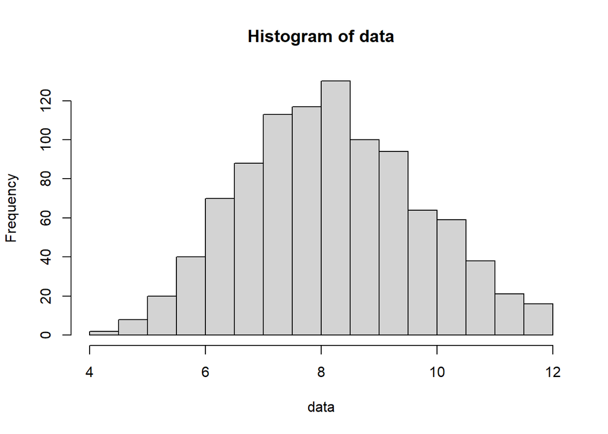

```r
hist(data)
```

Pelo histograma gerado, podemos ver que a distribuição dos dados sugere algum modelo que segue a normalidade

```r
mean_data=mean(data)
sd_data=sd(data)
```

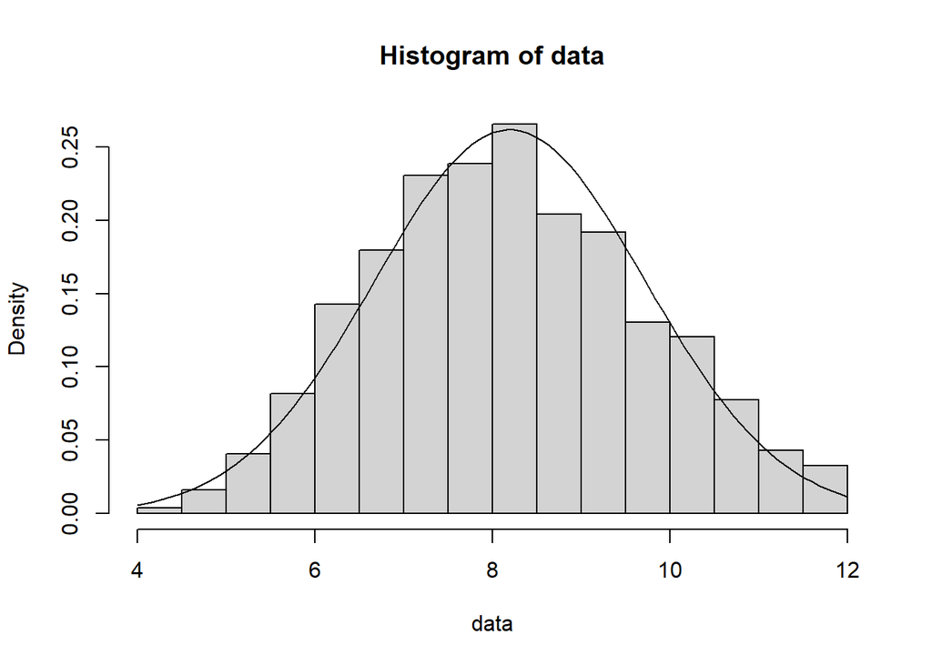

```r
hist(data,freq=F)
curve(dnorm(x,mean=mean_data,sd=sd_data),add=T)
```

Portanto, é possível ver que a utilização do modelo normal se encaixa muito bem aos dados

Assim, com um modelo em mãos, podemos começar o processo de simulação de tempo de chegada de maratonista na ultramaratona **Cortina Trail Dara Ultramaratona**.

1. Definindo $\lambda(t)$ e executando apenas uma simulação

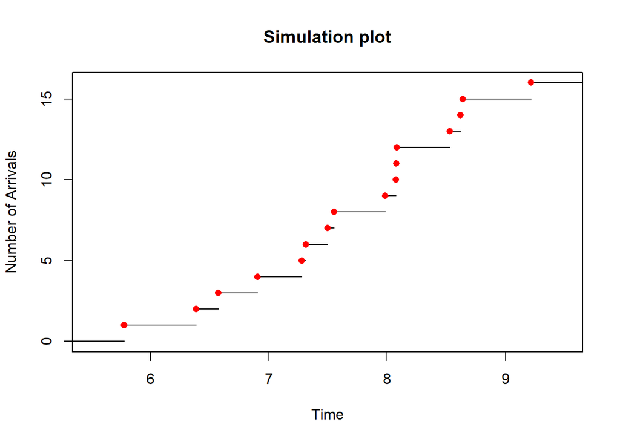

```r
lambda_t=function(t)dnorm(t,mean=mean_data,sd=sd_data)
teste=nhpp_simulation(lambda_t,0,16)
nhpp_view(teste)
```

2. Utilizando composição de Processos de Poisson para convergir a media esperada, onde foi observada uma boa convergencia para 80 composições

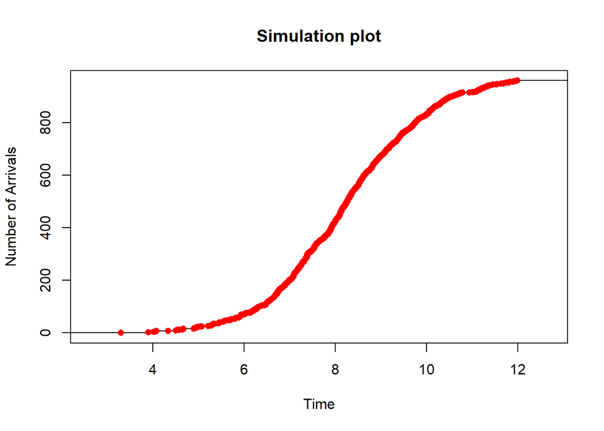

```r
teste=nhpp_simulation(lambda_t,0,16)
teste=unlist(replicate(80,nhpp_simulation(lambda_t,0,12),simplify = F))
teste=sort(teste)
nhpp_view(teste)
```

E portanto vemos, assim como descrito no modelo normal, um número maior de chegadas perto do valor de média = 8

## Ocorrencia de erros em uma rede wi-fi

Nesse exemplo usamos os dados retirados do trabalho científico **Modeling Poisson Error Process on Wireless Channels** de **Tibor Csóka, Jaroslav Polec**, disponível em : *https://citeseerx.ist.psu.edu/viewdoc/download?doi=10.1.1.1004.6699&rep=rep1&type=pdf*.

Se trata de um trabalho que busca modelar a probabilidade de ocorrencia de erros em redes wi-fi do tipo IEEE 802.11b.

Na conclusão dele, é descritos 3 modelos que tiveram um bom encaixe com os dados, sâo eles: MMPP-2 hiper-exponencial, Elliot e Gamma, onde o trabalho disserta sobre a preferencia para o uso do modelo MMPP-2 hiper-exponencial para aqueles dados e do modelo hiper-exponencial como chute inial para outras bases de dados.

(Base de dados e modelos propostos):

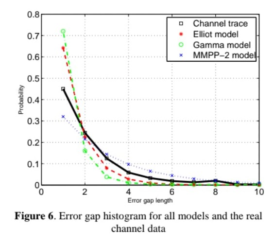

Assim, utilizando esse artigo como base, simularemos a quantidade de erros em uma rede wi-fi utilizando a distribuição hiper-exponencial como modelo, utilizando funções do pacote **sdprisk**

Buscando um modelo semelhante a aquele utilizado no trabalho, encontramos o valor para parametro $\lambda=0.6$ um bom valor para um teste de simulação

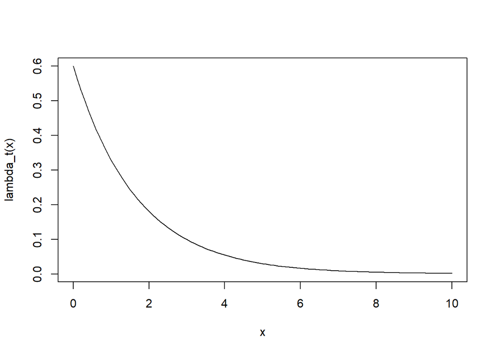

```r
lambda_t=function(t)dhypoexp(t,rate=0.6)
curve(lambda_t,0,10)
```

2. Simulando um evento de erros utilizando a função de intensidade descrita acima

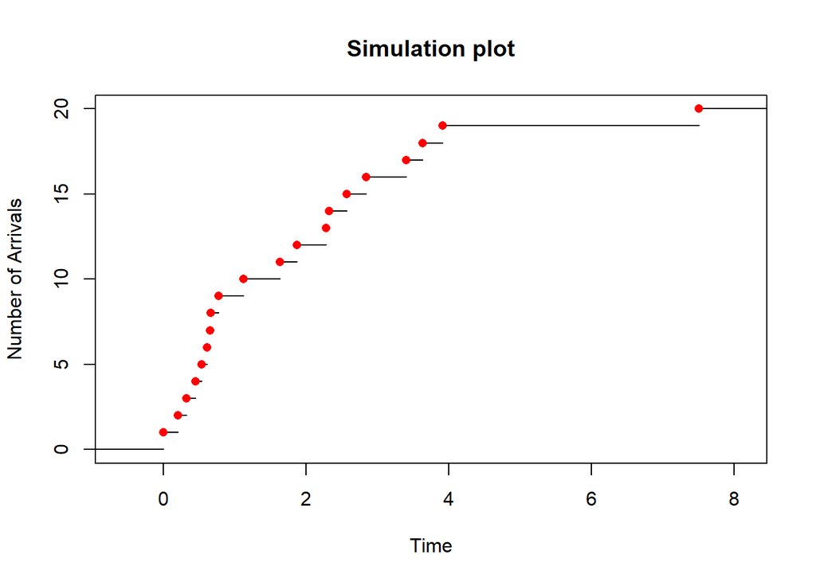

```r
data=nhpp_simulation(lambda_t,0,20)

nhpp_view(data)
```

E portanto vemos, assim como descrito no modelo, um número maior de ocorrências de erro na parte inicial da simulação